# MetaMarkers: robust marker signatures from single-cell data (hierarchical annotation vignette)

## Introduction

We assume that the reader is familiar with the main “MetaMarkers” vignette, which shows how to select meta-markers from a compendium of pancreas dataset. We also assume that the reader is somewhat familiar with the “Annotation” vignette, which performs cell type annotation using a flat hierarchy of cell types. In this vignette, we will focus on using *hierarchical* markers for cell type annotation, and show how to build a benchmark to find highly informative markers.

As in the main vignette, the requirements are: - a list of annotated datasets. - matching cell type names across datasets. - all packages installed in the main vignette.

We load the packages needed for our analysis: MetaMarkers, scRNAseq (package used to access datasets), dplyr (data manipulation, part of the tidyverse), and ggplot2 (figures, part of the tidyverse).

```r
library(MetaMarkers)
library(scRNAseq)
library(dplyr)
library(ggplot2)
```

## Prepare datasets

The 3 pancreas atlas datasets are built in a similar fashion to the “Annotation” vignette (see vignette for details). Briefly, we start by loading the data:

```r
dataset1 = scRNAseq::BaronPancreasData()
dataset2 = scRNAseq::MuraroPancreasData()
dataset3 = scRNAseq::SegerstolpePancreasData()
rownames(dataset2) = rowData(dataset2)$symbol
```

We normalize cell type names across datasets:

```r
new_label = dataset1$label
new_label[new_label=="activated_stellate"] = "mesenchymal"
new_label[new_label=="quiescent_stellate"] = "mesenchymal"
dataset1$new_label = new_label

new_label = dataset2$label
new_label[new_label=="duct"] = "ductal"
new_label[new_label=="pp"] = "gamma"
dataset2$new_label = new_label

new_label = dataset3$`cell type`
new_label = gsub(" cell", "", new_label)
new_label[new_label=="PSC"] = "mesenchymal"
dataset3$new_label = new_label

common_labels = Reduce(intersect, list(
    unique(dataset1$new_label), unique(dataset2$new_label), unique(dataset3$new_label)
))
```

We restrict datasets to common cell types and normalize data to CPM format:

```r
datasets = list(baron = dataset1, muraro = dataset2, seger = dataset3)
for (dataset in names(datasets)) {
    keep_cell = datasets[[dataset]]$new_label %in% common_labels
    datasets[[dataset]] = datasets[[dataset]][, keep_cell]
    cpm(datasets[[dataset]]) = convert_to_cpm(counts(datasets[[dataset]]))
}
```

Finally, we group cell types into 2 classes: endocrine and non-endocrine.

```r
for (dataset in names(datasets)) {
    class_label = rep("non-endocrine", ncol(datasets[[dataset]]))
    is_endocrine = datasets[[dataset]]$new_label %in% c("alpha", "beta", "gamma", "delta", "epsilon")
    class_label[is_endocrine] = "endocrine"
    datasets[[dataset]]$class = class_label
}
```

# Marker selection

We proceed to marker selection for each individual dataset.

```r
class_markers = lapply(datasets, function(dataset) {
    compute_markers(cpm(dataset), dataset$class)
})
names(class_markers) = names(datasets)
```

We use leave-one-dataset-out cross-validation: we build meta-markers from 2 datasets and predict on the third dataset. Then build meta-markers from invidual datasets marker lists, leaving one dataset out.

```r
class_meta_markers = lapply(names(class_markers), function(leave_out) {
    make_meta_markers(class_markers[names(class_markers) != leave_out])
})
names(class_meta_markers) = names(class_markers)
```

```r
ct_markers = lapply(datasets, function(dataset) {
    compute_markers(cpm(dataset), dataset$new_label, dataset$class)
})
names(ct_markers) = names(datasets)

ct_meta_markers = lapply(names(ct_markers), function(leave_out) {
    make_meta_markers(ct_markers[names(ct_markers) != leave_out])
})
names(ct_meta_markers) = names(ct_markers)
```

# Hierarchical cell type prediction

As an example, we start by predicting cell types from the Segerstolpe dataset using the top 100 Baron+Muraro meta-markers. First we select the top 100 meta-markers (leaving Segerstolpe out) for each cell type, then predict cell types in the Segerstolpe dataset:

```r
test_dataset = "seger"
top_markers = filter(class_meta_markers[[test_dataset]], rank<=100)
class_scores = score_cells(log1p(cpm(datasets[[test_dataset]])), top_markers)
class_enrichment = compute_marker_enrichment(class_scores)
class_pred = assign_cells(class_scores)
```

To find the ideal enrichment value, we could use the full cell type assessment, but for the class level we will use a simpler method:

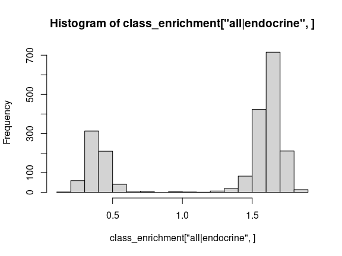

```r
hist(class_enrichment["all|endocrine",])
```

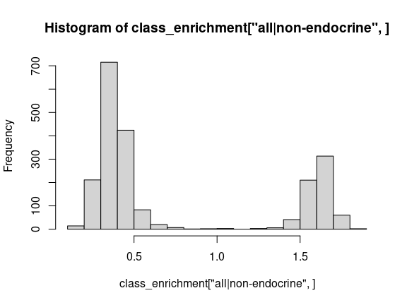

```r
hist(class_enrichment["all|non-endocrine",])
```

All class assignments are relatively clear, we’ll proceed with predictions at the cell type level assuming that we got all class-level predictions correct.

```r
top_markers = filter(ct_meta_markers[[test_dataset]], rank<=100)
ct_scores = score_cells(log1p(cpm(datasets[[test_dataset]])), top_markers)
ct_scores[1:6, 1:4]
```

```
#>                      HP1502401_H13 HP1502401_J14 HP1502401_B14 HP1502401_A14
#> endocrine|alpha          1.4261392     2.5060299     0.6677290     1.1405925
#> endocrine|beta           0.6447661     0.3714888     2.2928924     0.7626360
#> endocrine|delta          0.4853442     0.2922574     0.5198272     0.9128999
#> endocrine|epsilon        1.5662418     1.5074361     1.3391760     2.2365990
#> endocrine|gamma          2.3825213     0.9179555     1.0921466     1.4434280
#> non-endocrine|acinar     0.6922713     0.7389327     0.7701384     3.7716514
```

Note that scores encode group info, e.g. “endocrine|alpha”.

```r
ct_enrichment = compute_marker_enrichment(ct_scores, by_group = TRUE)
ct_pred = assign_cells(ct_scores, group_assignment = class_pred$predicted)
```

```r
ct_pred = ct_pred %>%
    mutate(true_label = datasets[[test_dataset]]$new_label)
mean(ct_pred$predicted == ct_pred$true_label)
```

```
#> [1] 0.9834515
```

Accuracy of 98.3%, almost 3 points higher than flat annotation (95.6%).

```r
logcounts(datasets[[test_dataset]]) = log1p(cpm(datasets[[test_dataset]]))
dec = scran::modelGeneVar(datasets[[test_dataset]])
hvg = scran::getTopHVGs(dec, n=2000)
umap = compute_umap(logcounts(datasets[[test_dataset]])[hvg,])
```

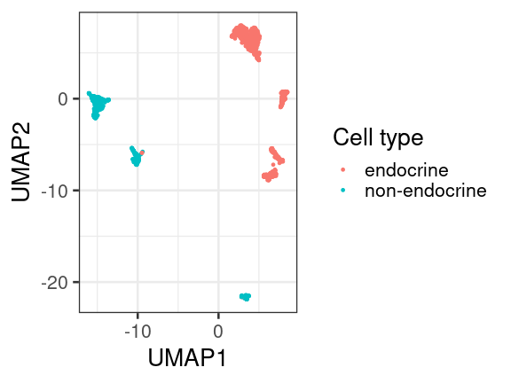

```r
plot_assignments(class_pred, umap[,2:3], 1)
```

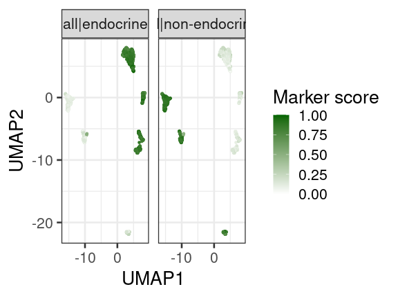

```r
plot_marker_scores(class_enrichment, umap[,2:3], TRUE)
```

Small group of cells that shows suspicious co-expression of endocrine and non-endocrine markers.

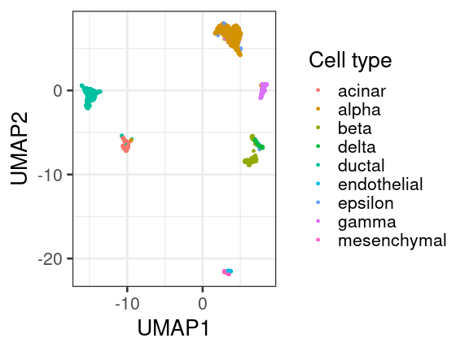

```r
plot_assignments(ct_pred, umap[,2:3], 1)
```

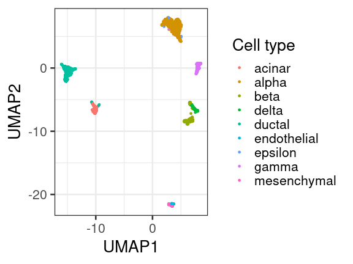

```r
ct_true = mutate(ct_pred, predicted = true_label)
plot_assignments(ct_true, umap[,2:3], 1)
```

Excellent correspondance, small differences: acinar/ductal, epsilon.

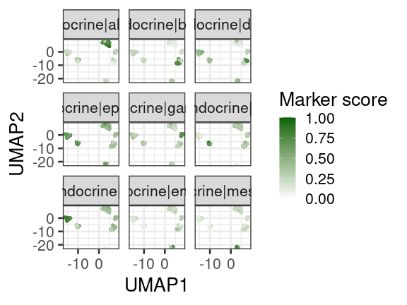

```r
plot_marker_scores(ct_enrichment, umap[,2:3], TRUE)
```

A potential issue that arises using the naive assignment method is that some marker sets contain higher expressing genes, which may lead to some cell types being overcalled. This is the case for the epsilon cell type for example:

```r
ct_pred %>%
    filter(true_label == "epsilon" | predicted == "epsilon") %>%
    arrange(desc(enrichment))
```

```
#>                      group predicted    score enrichment true_label
#> HP1504101T2D_M8  endocrine   epsilon 2.979479   2.208687    epsilon
#> HP1504901_C13    endocrine   epsilon 2.960608   2.007328    epsilon
#> HP1504901_F14    endocrine   epsilon 3.381199   1.975126    epsilon
#> HP1502401_E14    endocrine   epsilon 3.732720   1.951055    epsilon
#> HP1504901_D18    endocrine   epsilon 3.120062   1.846794    epsilon
#> HP1506401_J16    endocrine   epsilon 4.197370   1.811020    epsilon
#> HP1526901T2D_M13 endocrine   epsilon 3.733647   1.629074    epsilon
#> HP1504901_A21    endocrine   epsilon 1.637026   1.442909      delta
#> HP1502401_A18    endocrine   epsilon 2.134297   1.412343      delta
#> HP1506401_K22    endocrine   epsilon 2.845507   1.405126      gamma
#> HP1506401_E16    endocrine   epsilon 2.418455   1.390819      delta
#> HP1502401_O18    endocrine   epsilon 2.011736   1.388873      delta
#> HP1504101T2D_F17 endocrine   epsilon 2.101180   1.337459      delta
#> HP1502401_I7     endocrine   epsilon 1.794526   1.333946      delta
#> HP1526901T2D_E21 endocrine   epsilon 2.466985   1.327914      delta
#> HP1509101_H13    endocrine   epsilon 1.885645   1.308841      delta
#> HP1509101_O1     endocrine   epsilon 1.739345   1.297259      delta
#> AZ_A12           endocrine   epsilon 1.289100   1.295052      delta
#> AZ_D5            endocrine   epsilon 1.476539   1.290450      delta
#> HP1502401_C5     endocrine   epsilon 1.773942   1.290307      delta
#> AZ_B1            endocrine   epsilon 1.776223   1.283465      delta
#> HP1506401_G11    endocrine   epsilon 2.366990   1.283287      delta
#> HP1509101_L19    endocrine   epsilon 2.202080   1.241993      delta
#> HP1526901T2D_O7  endocrine   epsilon 2.469421   1.239878      delta
#> HP1526901T2D_A22 endocrine   epsilon 2.842576   1.221917      delta
#> HP1502401_G20    endocrine   epsilon 1.807740   1.209583      delta
#> AZ_H1            endocrine   epsilon 1.100528   1.205588      delta
#> HP1509101_E4     endocrine   epsilon 1.802103   1.197411      delta
#> HP1525301T2D_A7  endocrine   epsilon 2.329698   1.185019      delta
#> HP1526901T2D_C15 endocrine   epsilon 1.992869   1.182747      delta
#> HP1504901_J4     endocrine   epsilon 1.785599   1.171957      delta
```

31 cells are called as epsilon, but only 7 cells were annotated as epsilon. However “true” epsilon cells have much higher marker scores and enrichment values, which can help to hand curate cell-level annotations. One way to pick a threshold for scores and enrichment is to look for multimodality in the score and enrichment distributions:

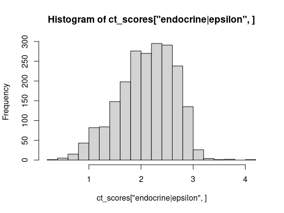

```r
hist(ct_scores["endocrine|epsilon",], breaks = 20)
```

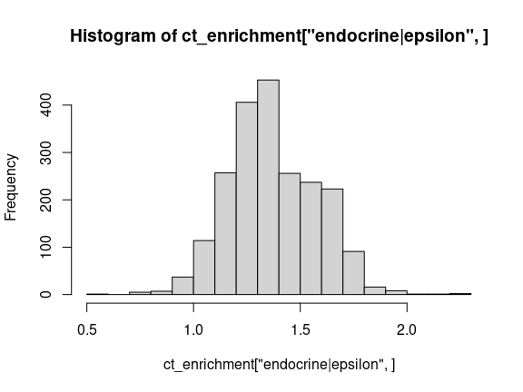

```r
hist(ct_enrichment["endocrine|epsilon",])
```

However, a better alternative is to assess cell type predictions across multiple training datasets to compute the optimal enrichment threshold above which a cell should be annotated as epsilon (1.8), as we will show below.

# Assessment of cell type prediction

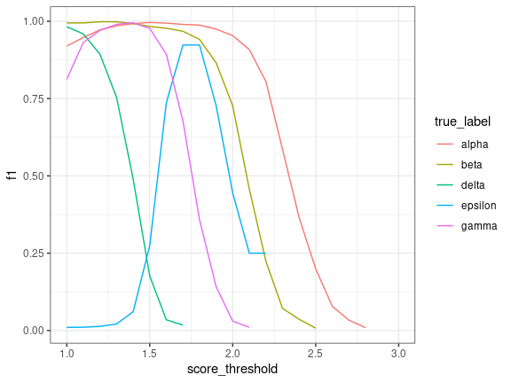

```r
true_labels = datasets[[test_dataset]]$new_label
keep_cell = datasets[[test_dataset]]$class == "endocrine"
keep_marker_set = get_group(rownames(ct_enrichment)) == "endocrine"
pr = summarize_precision_recall(
    ct_enrichment[keep_marker_set, keep_cell], true_labels[keep_cell], seq(1,3,0.1)
) %>%
    filter(get_cell_type(marker_set) == true_label)
pr %>%
    ggplot(aes(x = score_threshold, y = f1, col = true_label)) +
    geom_line() +
    theme_bw()
```

We repeat the same assessment using each dataset as the test dataset:

```r
test_class = "endocrine"
pr = list()
for (test_dataset in c("baron", "muraro", "seger")) {
    ct_markers = filter(ct_meta_markers[[test_dataset]], rank<=100)
    ct_scores = score_cells(log1p(cpm(datasets[[test_dataset]])), ct_markers)
    ct_enrichment = compute_marker_enrichment(ct_scores, by_group = TRUE)

    true_labels = datasets[[test_dataset]]$new_label
    keep_cell = datasets[[test_dataset]]$class == test_class
    keep_marker_set = get_group(rownames(ct_enrichment)) == test_class
    pr[[test_dataset]] = summarize_precision_recall(
        ct_enrichment[keep_marker_set, keep_cell], true_labels[keep_cell], seq(1,3,0.1)
    ) %>%
        filter(get_cell_type(marker_set) == true_label)
}
pr = bind_rows(pr, .id = "test_dataset")
```

Now we can compute the average F1 over all test datasets:

```r
mean_pr = pr %>%
    group_by(true_label, score_threshold) %>%
    summarize(f1 = mean(f1, na.rm=TRUE))
```

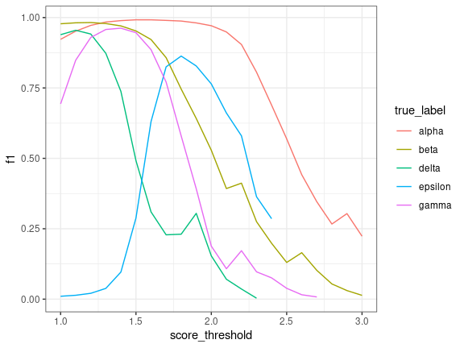

```r
mean_pr %>%
    ggplot(aes(x = score_threshold, y = f1, col = true_label)) +
    geom_line() +
    theme_bw()
```

And extract optimal performance and enrichment thresholds:

```r
mean_pr %>%
    group_by(true_label) %>%
    filter(f1 == max(f1, na.rm = TRUE)) %>%
    summarize(score_threshold = median(score_threshold), f1 = first(f1))
```

```
#> # A tibble: 5 x 3
#>   true_label score_threshold    f1
#>   <chr>                <dbl> <dbl>
#> 1 alpha                  1.5 0.992
#> 2 beta                   1.2 0.982
#> 3 delta                  1.1 0.955
#> 4 epsilon                1.8 0.863
#> 5 gamma                  1.4 0.962
```

For example, for epsilon cells, the optimal threshold is at 1.8, with an expected performance of F1=0.86.

# Estimation of number of informative markers per cell type

To estimate the number of ideal markers, we can repeat the previous assessment at different gene numbers:

```r
test_class = "endocrine"
n_genes = c(1, 2, 5, 10, 20, 50, 100, 200, 500, 1000)
mean_pr = list()
for (n in n_genes) {
    pr = list()
    for (test_dataset in c("baron", "muraro", "seger")) {
        ct_markers = filter(ct_meta_markers[[test_dataset]], rank<=n)
        ct_scores = score_cells(log1p(cpm(datasets[[test_dataset]])), ct_markers)
        ct_enrichment = compute_marker_enrichment(ct_scores, by_group = TRUE)

        true_labels = datasets[[test_dataset]]$new_label
        keep_cell = datasets[[test_dataset]]$class == test_class
        keep_marker_set = get_group(rownames(ct_enrichment)) == test_class
        pr[[test_dataset]] = summarize_precision_recall(
            ct_enrichment[keep_marker_set, keep_cell], true_labels[keep_cell], seq(1,3,0.1)
        ) %>%
            filter(get_cell_type(marker_set) == true_label)
    }
    pr = bind_rows(pr, .id = "test_dataset")
    mean_pr[[as.character(n)]] = pr %>%
        group_by(true_label, score_threshold) %>%
        summarize(f1 = mean(f1, na.rm=TRUE)) %>%
        group_by(true_label) %>%
        filter(f1 == max(f1, na.rm = TRUE)) %>%
        summarize(score_threshold = median(score_threshold), f1 = first(f1))
}
mean_pr = bind_rows(mean_pr, .id = "n_genes") %>%
    mutate(n_genes = as.integer(n_genes))
```

And plot the results:

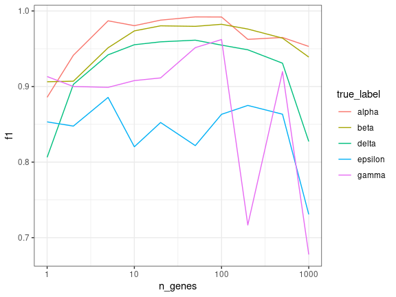

```r
mean_pr %>%
    ggplot(aes(x = n_genes, y = f1, col = true_label)) +
    geom_line() +
    theme_bw() +
    scale_x_log10()
```

Epsilon cells are mostly misannotated in the Baron dataset because of low quality cells.